# model_random_forest_corrige slides

#### 3 - Survie en fonction de l'âge

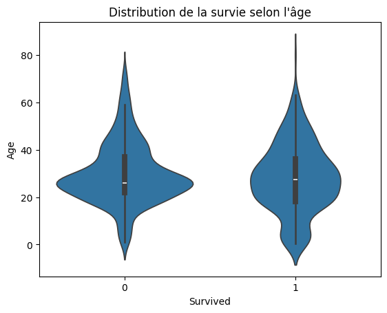

```python
sns.violinplot(x='Survived',
               y='Age',
               data=train_cleaned)
plt.title('Distribution de la survie selon l\'âge')
plt.show()
```

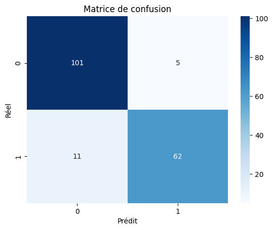

```python
cm = confusion_matrix(y_test, y_pred)
sns.heatmap(cm, annot=True, fmt='d',cmap='Blues')
plt.xlabel('Prédit')
plt.ylabel('Réel')
plt.title('Matrice de confusion')
plt.show()
```

### - Importance des variables

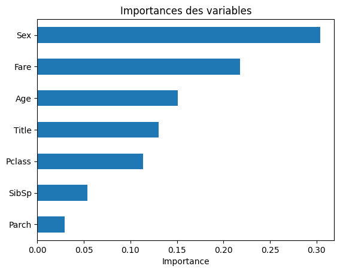

```python
importances = pd.Series(best_model.feature_importances_,
                        index=X.columns)
importances.sort_values().plot(kind='barh')
plt.title('Importances des variables')
plt.xlabel('Importance')
plt.show()
```

## XIII - Analyse réflexive (difficultés rencontrées)

- Démarche à suivre

  Sans feuille de route ou piste de travail à suivre, il a été compliqué d'aborder le brief. En effet, un certain nombres de notions étaient à connaître au préalable (concepts mathématiques, fonctionnement des modèles...) et nécessaires à la compréhension des attendus du brief. Ainsi, une grande partie de notre travail a été de rechercher des ressources en ligne couplé à l'utilisation de chatGPT pour nous guider progressivement.
- Manque de compréhension au sujet du Machine Learning (ML)

  Bien que le principe général du ML soit facilement compréhensible, son fonctionnement et les concepts derrière ce domaine en sont plus difficile d'accès: comme indiqué dans le point précédent, il est nécessaire d'avoir une connaissance de concepts mathématiques (notamment en statistiques et probabilités) pour appréhender le ML. Il est donc assez difficile - dans l'exercice demandé - d'expliquer clairement notre travail (Pourquoi avoir utilisé tel modèle au détriment d'un autre ? Comment interpréter les résultats de l'entrainement du modèle choisi, etc...).
- L'exploration/nettoyage des données

  Cette partie du travail a été probablement la plus longue mais la plus accessible. En effet, ayant déjà utilisé la librairie pandas, le traitement des données du brief nous a permis de pratiquer ce qui a été vu dans le brief Python. Le travail a donc été principalement d'interpréter les données et de les traiter en conséquence.
- TL;DR

  La difficulté première du brief repose sur l'absence de feuille de route pour travailler sur un concept tout à fait nouveau; Le domaine du Machine Learning requiert des connaissances préalables qui n'ont pas été abordées durant la formation et a rendu le travail complexe tant il était difficile de réellement comprendre ce que l'on faisait. La syntaxe, le code pour utiliser un modèle n'est pas compliqué mais la compréhension des paramètres et des résultats était bien plus difficile à comprendre. Hormis cet aspect là, le fait de reprendre l'utilisation des librairies pandas, plotly a permis d'approfondir/enrichir nos connaissances dans l'utilisation de Python.